# Projeto de Restauracion de Ecosistemas TESTE

Toa Quindi

2025-10-10

# 1 Introdución

Proyecto desarrollado para el modulo Fluxo de trabalho reproductivel em R, dictado por el professor Diogo Rocha y Hernani Ramos aplicado a un contexto de restauracion de ecosistema en la region sierra sur de Ecuador.

# 2 Objetivo general

Criar uma estructura de trabalho de base para pesquisa de restauraçao de ecossitemas aplicado en la áreas protegidas de la sierra sur de Equador.

## 2.1 Objetivos especificos

Definir las áreas de estudio Definira las variables para el análisis de la variación Analizar la variación de cada área desde el año 2000 hasta el año 2045

# 3 Tarefas do trabalho

- Criar repositorio em Github (ok)
- Criar planilha con dados simulados (excel) (ok)
- Criar planilha con dados simulados (Google sheets) (ok)
- Criar dados históticos simulados del año 2000 (ok)
- Conectar la planilha de datos con Github (ok)
- Conectar repositorio e planilha com Rstudio (ok)
- Criar relatorio Rmarkdown (ok)
- Checar impressao de relatorio em html (ok)
- Instalar MacTeX on macOS - https://tug.org/mactex/ ( )
- Checar impressao de relatorio em pdf (ok)
- Checar impressao de relatorio em word (ok)
- Fazer sumario estadistico de dados (ok)
- Organizar scripts (ok)

## 3.1 Pacotes

```r
# instalacion y abrir pacotes
# install.packages(terra)
# install.packages(ggplot2)
# install.packages(dplyr)
# tinytex::install_tinytex() #Para windows
# install.packages(MacTex) #Para mac instalar
# install.packages(readxl)
# install.packages("sf")
# install.packages("ggspatial")
# install.packages("ggsn")

library(terra)
library(ggplot2)
library(dplyr)
library(readr)
library(googlesheets4) #código que abre o pacote.
library(sf)
library(rnaturalearth)
library(rnaturalearthdata) # Datos necesarios para rnaturalearth
library(ggspatial)
```

## 3.2 Conexión con repositorio de dados

planilha https://docs.google.com/spreadsheets/d/1_pp_YBuU1xgU2OD62DSHViigh90yhGJR2DeAujrFY3A/edit?usp=sharing

| Id | ano | area | ecosistema | score_no_n | score_no_c | score_yes_n | score_yes_c | score | long | lat |
| --- | --- | --- | --- | --- | --- | --- | --- | --- | --- | --- |
| 1 | 2000 | Reserva1 | Paramo | 4 | IV | 4 | IV | bom | -79.088 | -3.493 |
| 2 | 2000 | Reserva1 | Paramo | 4 | IV | 4 | IV | bom | -79.069 | -3.614 |
| 3 | 2000 | Reserva1 | Paramo | 5 | V | 5 | V | optimo | -79.096 | -3.581 |
| 4 | 2000 | Reserva1 | Paramo | 4 | IV | 4 | IV | bom | -79.092 | -3.611 |
| 5 | 2000 | Reserva1 | Paramo | 5 | V | 5 | V | optimo | -79.132 | -3.521 |
| 6 | 2000 | Reserva1 | Paramo | 4 | IV | 4 | IV | bom | -79.127 | -3.510 |
| 7 | 2000 | Reserva1 | Paramo | 5 | V | 5 | V | optimo | -79.121 | -3.533 |
| 8 | 2000 | Reserva1 | Paramo | 5 | V | 5 | V | optimo | -79.090 | -3.572 |
| 9 | 2000 | Reserva1 | Paramo | 5 | V | 5 | V | optimo | -79.061 | -3.569 |
| 10 | 2000 | Reserva1 | Paramo | 5 | V | 5 | V | optimo | -79.098 | -3.530 |

[output cut: 470 more lines]

### 3.2.1 Sumario estadístico

```r
summary(datos)
```

```
##        Id             ano           area            ecosistema
##  Min.   :  1.0   Min.   :2000   Length:480         Length:480
##  1st Qu.:120.8   1st Qu.:2025   Class :character   Class :character
##  Median :240.5   Median :2032   Mode  :character   Mode  :character
##  Mean   :223.8   Mean   :2029
##  3rd Qu.:320.2   3rd Qu.:2040
##  Max.   :440.0   Max.   :2045
##    score_no_n     score_no_c         score_yes_n    score_yes_c
##  Min.   :1.000   Length:480         Min.   :1.000   Length:480
##  1st Qu.:2.000   Class :character   1st Qu.:2.000   Class :character
##  Median :4.000   Mode  :character   Median :4.000   Mode  :character
##  Mean   :3.263                      Mean   :3.423
##  3rd Qu.:5.000                      3rd Qu.:5.000
##  Max.   :5.000                      Max.   :5.000
##     score                long             lat
##  Length:480         Min.   :-79.14   Min.   :-3.614
##  Class :character   1st Qu.:-79.10   1st Qu.:-3.540
##  Mode  :character   Median :-78.80   Median :-3.091
##                     Mean   :-78.81   Mean   :-3.101
##                     3rd Qu.:-78.52   3rd Qu.:-2.655
##                     Max.   :-78.50   Max.   :-2.621
```

## 3.3 Area de estudo

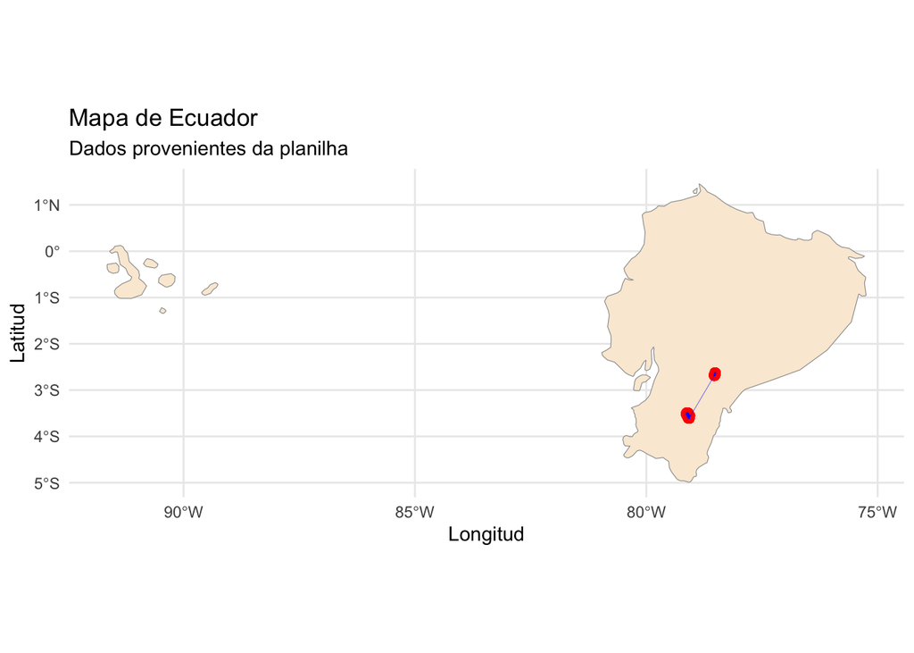

```r
#Escala nacional
#Datos de los países del mundo
world <- ne_countries(scale = "medium", returnclass = "sf")

#Filtrar el país deseado
ecuador <- subset(world, sovereignt == "Ecuador")

#Dibujar el mapa
datos_sf <- st_as_sf(datos, coords = c("long", "lat"), crs = 4326)  #WGS84

linha_sf <- datos_sf %>%
  summarize(do_union = FALSE) %>%
  st_cast("LINESTRING")

ggplot(data = ecuador) +
  geom_sf(fill = "antiquewhite", color = "gray60") +
  geom_sf(data = datos_sf, color = "red", size = 2) +        #pontos
  geom_sf(data = linha_sf, color = "blue", size = 0.1) +       #linha conectando
  labs(
    title = "Mapa de Ecuador",
    subtitle = "Dados provenientes da planilha",
    x = "Longitud", y = "Latitud"
  ) +
  theme_minimal()
```

```r
#Escala regional
getwd()
```

```
## [1] "/Users/pacha_cutig/Documents/Fluxo_trabalho_reproductivel_R/T_final/restauracion_ecosistemas"
```

```r
ruta_archivo <- setwd("/Users/pacha_cutig/Documents/Fluxo_trabalho_reproductivel_R/T_final/restauracion_ecosistemas")
shp1 <- st_read("Shp/Limite_prov_2019_est.shp")
shp2 <- st_read("Shp/SNAP_areas_est.shp")
```

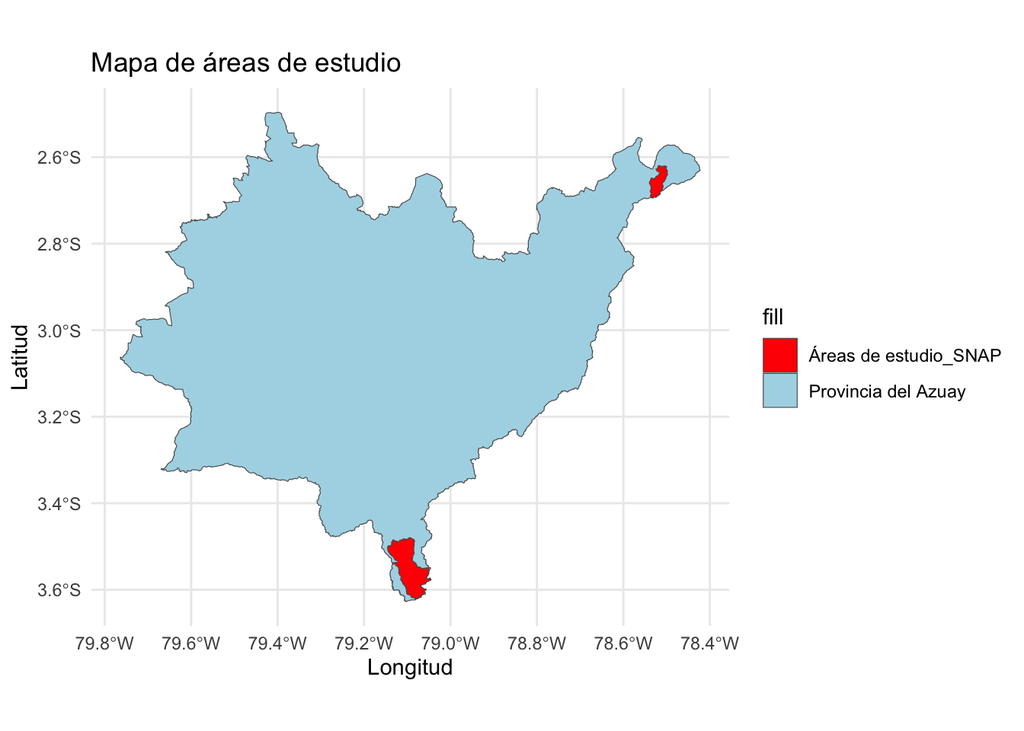

```r
datos_sf <- st_as_sf(datos, coords = c("long", "lat"), crs = 4326)

ggplot() +
  geom_sf(data = shp1, aes(fill = "Provincia del Azuay")) +
  geom_sf(data = shp2, aes(fill = "Áreas de estudio_SNAP")) +
  scale_fill_manual(values = c("Provincia del Azuay" = "lightblue", "Áreas de estudio_SNAP" = "red")) +
  labs(title = "Mapa de áreas de estudio",
       x = "Longitud",
       y = "Latitud") +
  theme_minimal() # Aplica un tema más limpio
```

### 3.3.1 Extracción de coordenadas máx y min

```r
bbox <- st_bbox(shp2)
print(bbox)
```

```
##       xmin       ymin       xmax       ymax
## -79.145966  -3.623105 -78.497602  -2.619635
```

### 3.3.2 Extracción de centroides

```r
centroides <- st_centroid(shp2)  #Generar coodenadas de centroides
coordenadas_xy <- st_coordinates(centroides)   #Para todos los centroides
print(coordenadas_xy)
```

```
##              X         Y
## [1,] -79.09615 -3.547965
## [2,] -78.51910 -2.656863
```

### 3.3.3 Tabelas

```r
#Ver las primeras filas de la tabla (como un data.frame)
head(st_drop_geometry(shp2))
```

|  | codigo_de_ | csnap | nam | map | ror | rom | subap | esc | psj | are | edel | txt |
| --- | --- | --- | --- | --- | --- | --- | --- | --- | --- | --- | --- | --- |
| 1 | FA210 | HB01057 | MARCOS PEREZ DE CASTILLA | AREA PROTEGIDA COMUNITARIA | ACUERDO MINISTERIAL NO. 036 DEL 23/04/2019 | SIN MODIFICACION | COMUNITARIO | 50000 | TERRESTRE | 8425.229 | EN REVISIÓN | SPN |
| 2 | FA210 | HB01055 | RIO NEGRO SOPLADORA | PARQUE NACIONAL | ACUERDO MINIATERIAL NO. 009DEL 23/01/2018 | ACUERDO MINISTERIAL NO.21 DEL 05 DE AGOSTO DE 2020 | ESTATAL | 5000 | TERRESTRE | 2175.673 | CONCLUIDO | SPN |

```r
#Convertir la tabla a un data.frame sin geometría
tabla <- st_drop_geometry(shp2)

#Proyección de datos
st_crs(shp2)
```

```
## Coordinate Reference System:
##   User input: WGS 84
##   wkt:
## GEOGCRS["WGS 84",
##     DATUM["World Geodetic System 1984",
##         ELLIPSOID["WGS 84",6378137,298.257223563,
##             LENGTHUNIT["metre",1]]],
##     PRIMEM["Greenwich",0,
##         ANGLEUNIT["degree",0.0174532925199433]],
##     CS[ellipsoidal,2],
##         AXIS["latitude",north,
##             ORDER[1],
##             ANGLEUNIT["degree",0.0174532925199433]],
##         AXIS["longitude",east,
##             ORDER[2],
##             ANGLEUNIT["degree",0.0174532925199433]],
##     ID["EPSG",4326]]
```

```r
#Reproyectar a UTM adecuado (ajustar el EPSG según la zona)
shp2_m <- st_transform(shp2, 32717)
shp2_m$area_m2 <- st_area(shp2_m)
shp2_m$area_km2 <- as.numeric(shp2_m$area_m2) / 1e6

head(st_drop_geometry(shp2_m))
```

|  | codigo_de_ | csnap | nam | map | ror | rom | subap | esc | psj | are | edel | txt | area_m2 | area_km2 |
| --- | --- | --- | --- | --- | --- | --- | --- | --- | --- | --- | --- | --- | --- | --- |
| 1 | FA210 | HB01057 | MARCOS PEREZ DE CASTILLA | AREA PROTEGIDA COMUNITARIA | ACUERDO MINISTERIAL NO. 036 DEL 23/04/2019 | SIN MODIFICACION | COMUNITARIO | 50000 | TERRESTRE | 8425.229 | EN REVISIÓN | SPN | 84252294 [m^2] | 84.25229 |
| 2 | FA210 | HB01055 | RIO NEGRO SOPLADORA | PARQUE NACIONAL | ACUERDO MINIATERIAL NO. 009DEL 23/01/2018 | ACUERDO MINISTERIAL NO.21 DEL 05 DE AGOSTO DE 2020 | ESTATAL | 5000 | TERRESTRE | 2175.673 | CONCLUIDO | SPN | 21756727 [m^2] | 21.75673 |

## 3.4 Análisis

```r
#Tablas de cvs
datos <- read_sheet(url_dados, sheet = "datos")

#Ver filas y columnas específicas
datos_res <- datos|>
  filter(area == "Reserva1") |>
  select(2, 3, 4, 7, 9)
head(datos_res, 40)
```

| ano | area | ecosistema | score_yes_n | score |
| --- | --- | --- | --- | --- |
| 2000 | Reserva1 | Paramo | 4 | bom |
| 2000 | Reserva1 | Paramo | 4 | bom |
| 2000 | Reserva1 | Paramo | 5 | optimo |
| 2000 | Reserva1 | Paramo | 4 | bom |
| 2000 | Reserva1 | Paramo | 5 | optimo |
| 2000 | Reserva1 | Paramo | 4 | bom |
| 2000 | Reserva1 | Paramo | 5 | optimo |
| 2000 | Reserva1 | Paramo | 5 | optimo |
| 2000 | Reserva1 | Paramo | 5 | optimo |
| 2000 | Reserva1 | Paramo | 5 | optimo |

[output cut: 30 more lines]

## 3.5 Gráficos

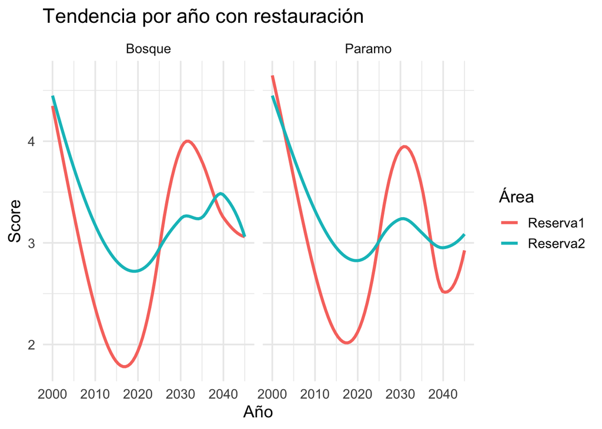

```r
#Criar mapas con serie histórica de evolucion desde el 2000 hasta 20 años de monitoreo de restauración.
datos <- read_sheet(url_dados, sheet = "datos")

ggplot(datos, aes(x = ano, y = score_yes_n, color = area)) +
  geom_smooth(se = FALSE, size = 1.2, method = "loess") +
  facet_wrap(~ ecosistema) +
  labs(
    title = "Tendencia por año con restauración",
    x = "Año",
    y = "Score",
    color = "Área"
  ) +
  theme_minimal(base_size = 14)
```

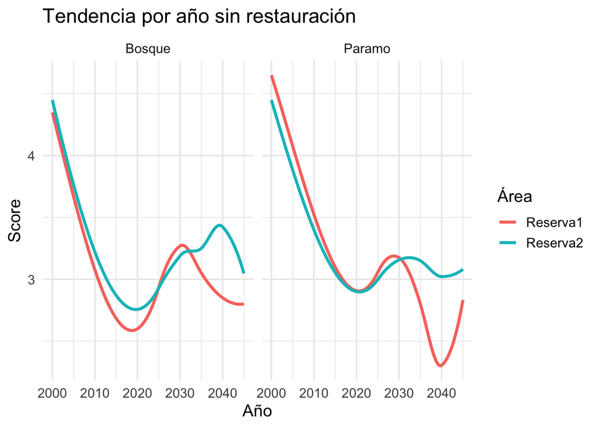

```r
ggplot(datos, aes(x = ano, y = score_no_n, color = area)) +
  geom_smooth(se = FALSE, size = 1.2, method = "loess") +
  facet_wrap(~ ecosistema) +
  labs(
    title = "Tendencia por año sin restauración",
    x = "Año",
    y = "Score",
    color = "Área"
  ) +
  theme_minimal(base_size = 14)
```